# Bike_Sale

MAMADY III DIAKITE

2024-06-04

This dataset contains information related to bike sales across various European regions.

Original Dataset Link : https://www.kaggle.com/datasets/sadiqshah/bike-sales-in-europe

## Exploratory and descriptive data analysis: Use “Exploratory and descriptive data analysis”. Talk about categorical and quantitative data or your ordinal variables

```r
Data <- read.csv("Bike_Sales1.csv")
data <- data.frame(Data)
datatable(data, options = list(scrollX = TRUE, scrollY = "200px"))
```

|  | Date | Day | Month | Year | Customer_Age | Age_Group | Customer_Gender | Country | State | Product_Category | Sub_Category | Product | Order_Quantity | Unit_Cost | Unit_Price | Profit | Cost | Revenue |
| --- | --- | --- | --- | --- | --- | --- | --- | --- | --- | --- | --- | --- | --- | --- | --- | --- | --- | --- |
| 1 | 11/26/2013 | 26 | November | 2013 | 19 | Youth (&lt;25) | Male | Canada | British Columbia | Accessories | Bike Racks | Hitch Rack - 4-Bike | 8 | 45 | 120 | 590 | 360 | 950 |
| 2 | 11/26/2015 | 26 | November | 2015 | 19 | Youth (&lt;25) | Male | Canada | British Columbia | Accessories | Bike Racks | Hitch Rack - 4-Bike | 8 | 45 | 120 | 590 | 360 | 950 |
| 3 | 3/23/2014 | 23 | March | 2014 | 49 | Adults (35-64) | Male | Australia | New South Wales | Accessories | Bike Racks | Hitch Rack - 4-Bike | 23 | 45 | 120 | 1366 | 1035 | 2401 |
| 4 | 3/23/2016 | 23 | March | 2016 | 49 | Adults (35-64) | Male | Australia | New South Wales | Accessories | Bike Racks | Hitch Rack - 4-Bike | 20 | 45 | 120 | 1188 | 900 | 2088 |
| 5 | 5/15/2014 | 15 | May | 2014 | 47 | Adults (35-64) | Female | Australia | New South Wales | Accessories | Bike Racks | Hitch Rack - 4-Bike | 4 | 45 | 120 | 238 | 180 | 418 |
| 6 | 5/15/2016 | 15 | May | 2016 | 47 | Adults (35-64) | Female | Australia | New South Wales | Accessories | Bike Racks | Hitch Rack - 4-Bike | 5 | 45 | 120 | 297 | 225 | 522 |
| 7 | 5/22/2014 | 22 | May | 2014 | 47 | Adults (35-64) | Female | Australia | Victoria | Accessories | Bike Racks | Hitch Rack - 4-Bike | 4 | 45 | 120 | 199 | 180 | 379 |
| 8 | 5/22/2016 | 22 | May | 2016 | 47 | Adults (35-64) | Female | Australia | Victoria | Accessories | Bike Racks | Hitch Rack - 4-Bike | 2 | 45 | 120 | 100 | 90 | 190 |
| 9 | 2/22/2014 | 22 | February | 2014 | 35 | Adults (35-64) | Male | Australia | Victoria | Accessories | Bike Racks | Hitch Rack - 4-Bike | 22 | 45 | 120 | 1096 | 990 | 2086 |
| 10 | 2/22/2016 | 22 | February | 2016 | 35 | Adults (35-64) | Male | Australia | Victoria | Accessories | Bike Racks | Hitch Rack - 4-Bike | 21 | 45 | 120 | 1046 | 945 | 1991 |

[output cut: 940 more lines]

```r
# Check for NA values
is_na_data <- is.na(data)

# Summarize the NA values for each column
na_summary <- colSums(is_na_data)

vars_to_factor <- c("Date", "Month", "Age_Group","Customer_Gender","Country","State","Product_Category","Sub_Category","Product")
# Convert variables to factors using lapply
data[vars_to_factor] <- lapply(data[vars_to_factor], factor)
skim(data)
```

Data summary

| Name | data |
| --- | --- |
| Number of rows | 950 |
| Number of columns | 18 |
| _______________________ |  |
| Column type frequency: |  |
| factor | 9 |
| numeric | 9 |
| ________________________ |  |
| Group variables | None |

**Variable type: factor**

| skim_variable | n_missing | complete_rate | ordered | n_unique | top_counts |
| --- | --- | --- | --- | --- | --- |
| Date | 0 | 1 | FALSE | 544 | 10/: 5, 10/: 5, 11/: 5, 11/: 5 |
| Month | 0 | 1 | FALSE | 12 | May: 116, Dec: 90, Sep: 90, Aug: 88 |
| Age_Group | 0 | 1 | FALSE | 4 | Adu: 506, You: 324, You: 114, Sen: 6 |
| Customer_Gender | 0 | 1 | FALSE | 2 | Mal: 484, Fem: 466 |
| Country | 0 | 1 | FALSE | 6 | Uni: 352, Aus: 190, Can: 148, Uni: 102 |
| State | 0 | 1 | FALSE | 29 | Cal: 196, Bri: 144, Eng: 102, Was: 102 |
| Product_Category | 0 | 1 | FALSE | 1 | Acc: 950 |
| Sub_Category | 0 | 1 | FALSE | 2 | Bik: 592, Bik: 358 |
| Product | 0 | 1 | FALSE | 2 | Hit: 596, All: 354 |

**Variable type: numeric**

| skim_variable | n_missing | complete_rate | mean | sd | p0 | p25 | p50 | p75 | p100 | hist |
| --- | --- | --- | --- | --- | --- | --- | --- | --- | --- | --- |
| Day | 0 | 1 | 16.16 | 8.84 | 1 | 9 | 17.0 | 24 | 31 | ▇▆▇▇▇ |
| Year | 0 | 1 | 2014.52 | 1.12 | 2013 | 2014 | 2014.5 | 2016 | 2016 | ▇▇▁▇▇ |
| Customer_Age | 0 | 1 | 37.35 | 11.33 | 17 | 29 | 36.0 | 45 | 87 | ▇▇▅▁▁ |
| Order_Quantity | 0 | 1 | 7.00 | 5.70 | 1 | 3 | 6.0 | 9 | 30 | ▇▅▁▁▁ |
| Unit_Cost | 0 | 1 | 50.22 | 6.77 | 45 | 45 | 45.0 | 59 | 59 | ▇▁▁▁▅ |
| Unit_Price | 0 | 1 | 134.53 | 18.87 | 120 | 120 | 120.0 | 159 | 159 | ▇▁▁▁▅ |
| Profit | 0 | 1 | 489.83 | 390.37 | 49 | 215 | 407.0 | 635 | 2214 | ▇▃▁▁▁ |
| Cost | 0 | 1 | 343.02 | 261.01 | 45 | 177 | 295.0 | 450 | 1350 | ▇▅▁▁▁ |
| Revenue | 0 | 1 | 832.85 | 647.35 | 94 | 372 | 706.0 | 1069 | 3564 | ▇▅▁▁▁ |

The categorical data includes variables like Date, Month, Age_Group, Customer_Gender, Country, State, Product_Category, Sub_Category, and Product. These show distributions such as top months, age groups, gender distribution, and product categories.

The numeric data includes variables such as Day, Year, Customer_Age, Order_Quantity, Unit_Cost, Unit_Price, Profit, Cost, and Revenue, with their means, standard deviations, and quartiles detailed.

Based on the given summary, we can see that there are no ordinal variables present.

There are no missing values, and provides insights into both demographics and financial metrics related to product sales.

## Data Visualization: Use 2 useful, meaningful and different “data visualization techniques” which will help you understand data further (distribution, outliers, variability). And use another 2 visualizations to compare two groups (like female/male; smoker/non-smoker etc). For each visualization.

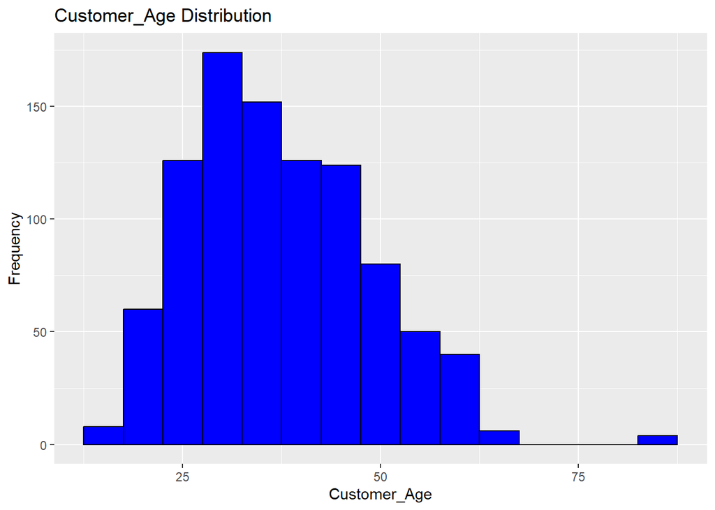

```r
# Histogram
ggplot(data, aes(x = Customer_Age)) +
  geom_histogram(binwidth = 5, fill = "blue", color = "black") +
  labs(title = "Customer_Age Distribution", x = "Customer_Age", y = "Frequency")
```

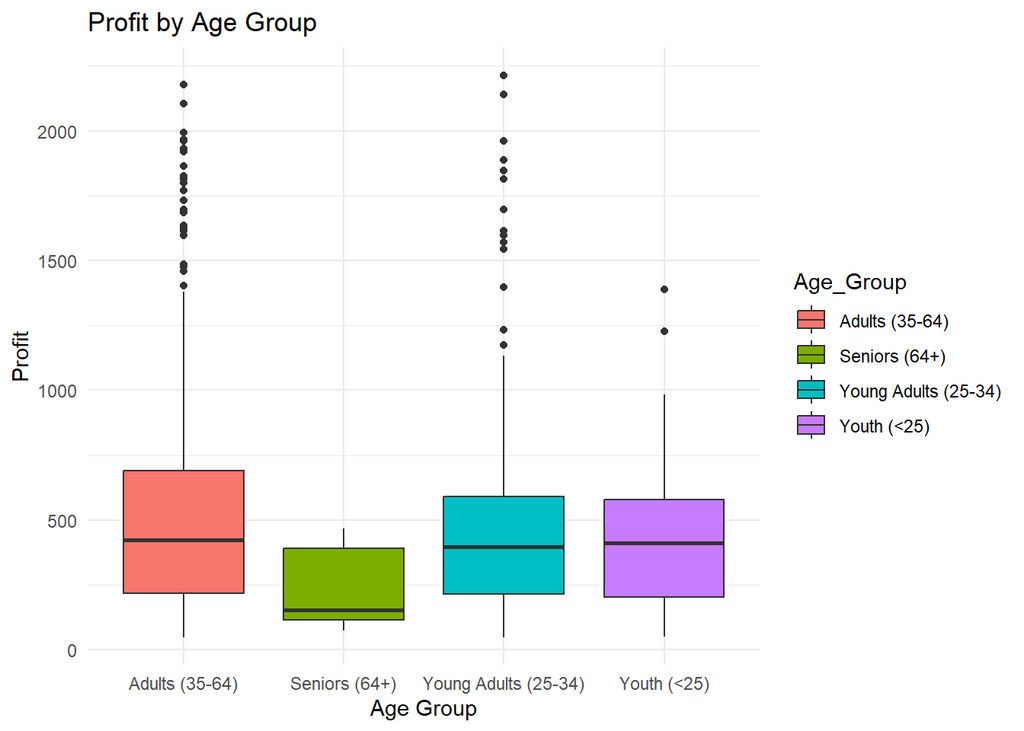

```r
# Box Plot for Profit by Age Group
ggplot(data, aes(x = Age_Group, y = Profit, fill = Age_Group)) +
  geom_boxplot() +
  labs(title = "Profit by Age Group", x = "Age Group", y = "Profit") +
  theme_minimal()
```

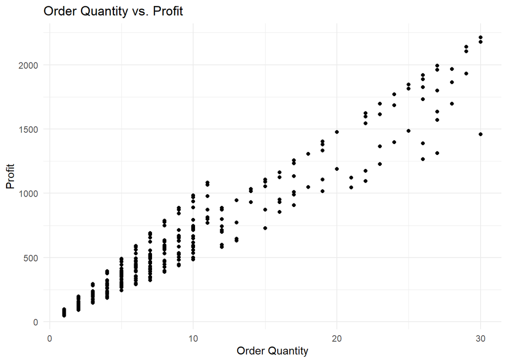

```r
# Scatter Plot for Order Quantity vs. Profit
ggplot(data, aes(x = Order_Quantity, y = Profit)) +
  geom_point(color = "black") +
  labs(title = "Order Quantity vs. Profit", x = "Order Quantity", y = "Profit") +
  theme_minimal()
```

Here, The scatter plot shows a positive correlation between order quantity and profit. As the order quantity increases, the profit also tends to increase, means that larger orders generally result in higher profits. The relationship appears to be linear,there is some variability at higher order quantities.

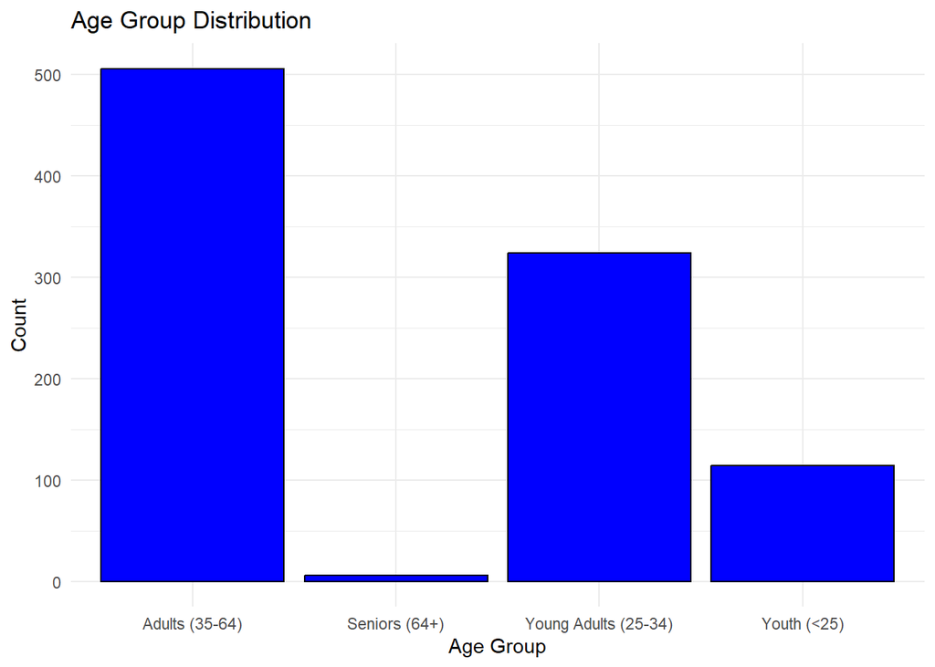

```r
#Bar Chart for Age Group Distribution
ggplot(data, aes(x = Age_Group)) +
  geom_bar(fill = "blue", color = "black") +
  labs(title = "Age Group Distribution", x = "Age Group", y = "Count") +
  theme_minimal()
```

The bar chart displays the distribution of different age groups, showing that adults (ages 35-64) have the highest count, followed by young adults (ages 25-34), and then youth (under 25). Seniors (ages 64+) have the lowest count, significantly less than the other age groups. The chart highlights a notable concentration of individuals in the adult age group.

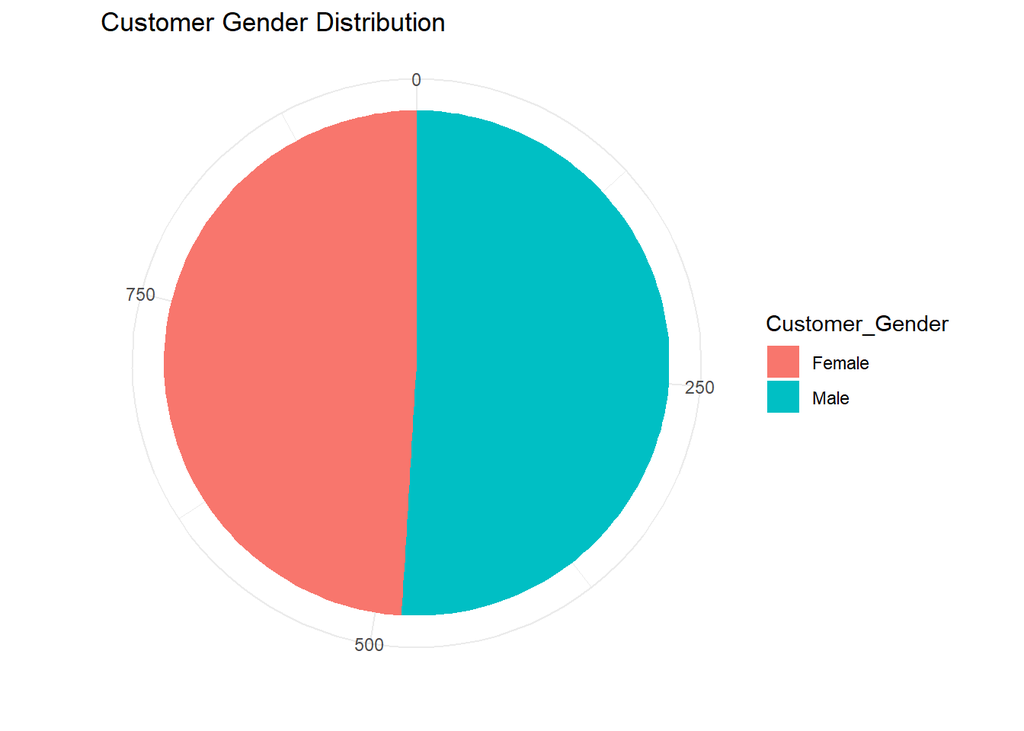

```r
# Pie Chart for Customer Gender Distribution
gender_count <- data %>%
  count(Customer_Gender)
ggplot(gender_count, aes(x = "", y = n, fill = Customer_Gender)) +
  geom_bar(stat = "identity", width = 1) +
  coord_polar("y") +
  labs(title = "Customer Gender Distribution", x = "", y = "") +
  theme_minimal()
```

The pie chart shows the distribution of customer gender, with females (F) and males (M) each comprising roughly half of the customer base. The visual representation indicates a nearly equal distribution between the two genders, suggesting balanced gender representation among the customers.

## Confidence Intervals: Build ‘2 Confidence Intervals’ step by step: a) Calculate the mean, then b) standard error, and then c) the CI.

```r
calculate_confidence_itervals_and_normality <- function(data, variable) {

  # Calculate the mean for the variable
  mean_variable <- mean(data[[variable]])

  # Calculate the standard error for the variable
  se_variable <- sd(data[[variable]]) / sqrt(length(data[[variable]]))

  # Calculate the confidence intervals for the variable
  ci_variable <- mean_variable + c(-1.96, 1.96) * se_variable

  # Perform normality test
  normality_test <- shapiro.test(data[[variable]])

  # Check if confidence intervals are symmetric
  is_symmetric <- all(diff(ci_variable) > 0)

  if(!is_symmetric){

  }
  # Print the results
  cat("Variable:", variable, "\n")
  cat("Normality Test p-value:", normality_test$p.value, "\n")
  cat("Confidence Intervals:", ci_variable, "\n")
  cat("Is Symmetric:", is_symmetric, "\n\n")
}

calculate_confidence_itervals_and_normality(data, "Order_Quantity")
```

```
## Variable: Order_Quantity
## Normality Test p-value: 6.34112e-32
## Confidence Intervals: 6.63828 7.363826
## Is Symmetric: TRUE
```

```r
calculate_confidence_itervals_and_normality(data, "Profit")
```

```
## Variable: Profit
## Normality Test p-value: 2.854566e-29
## Confidence Intervals: 465.0055 514.6535
## Is Symmetric: TRUE
```

First, let’s look at the confidence interval calculated for the variable “Order_Quantity” . The results show a range between 6.63828 and 7.363826 . This indicates that there is a 95% probability that the mean value of “Order_Quantity” falls within this interval.Therefore, based on these sample-based estimates, it is highly likely that the population mean of “Order_Quantity” lies within this range.

Secondly, let’s examine the confidence interval calculated for the variable “Profit”. The results show a range between 465.0055 and 514.6535. This indicates that there is a 95% probability that the mean value of “Profit” falls within this interval. Therefore, based on these sample-based estimates, it is highly likely that the population mean of “Profit” lies within this range.

In summary, these confidence intervals represent the intervals within which the population means of the respective variables are estimated based on the sample.In both cases, we can confidently say that the estimates based on the sample data are reliable, and there is a high probability that the true population mean values fall within these intervals.

## Transformation: Implement one transformation (log transformation, Box-Cok transformation) for one of the quantitative variables, which is not normally distributed; but will be normal or more normal, after the transformation.

```r
# Apply log transformation
data$Revenue <- log(data$Revenue)
calculate_confidence_itervals_and_normality(data,"Revenue")
```

```
## Variable: Revenue
## Normality Test p-value: 1.14588e-13
## Confidence Intervals: 6.367223 6.473118
## Is Symmetric: TRUE
```

## Every item if not indicated t-test (Welch t-test or Wilcoxon rank-sum test or Paired t-test) Implement a single t-test for one of the “normally or not-normally distributed” variable:

#### a.Aim In words, what is the objective here?

The objective is to determine if there is a significant association between the “Order_Quantity” and “Profit” variables.

#### b.Hypothesis and level of significance: Write hypothesis in scientific form and determine thelevel of significance.

H0 (null hypothesis): There is no significant difference between the means of “Order_Quantity” and “Profit” variables.

H1 (alternative hypothesis): There is a significant difference between the means of “Order_Quantity” and “Profit” variables. Level of significance (α): 0.05

#### c. Which test can we choose Is your data independent or dependent? Tell why we chose this test.

Since we are comparing the means of two independent variables, we can use the independent samples t-test. The assumptions for the t-test are: For this analysis, we will choose the independent samples t-test because we are comparing the means of two independent variables.

#### Assumption Check : Check the required assumptions statistically and “comment for each of them is a must!”.

Assumption 1: Independence No specific statistical test is required for this assumption as it is assumed based on the data collection process.

Assumption 2: Normality

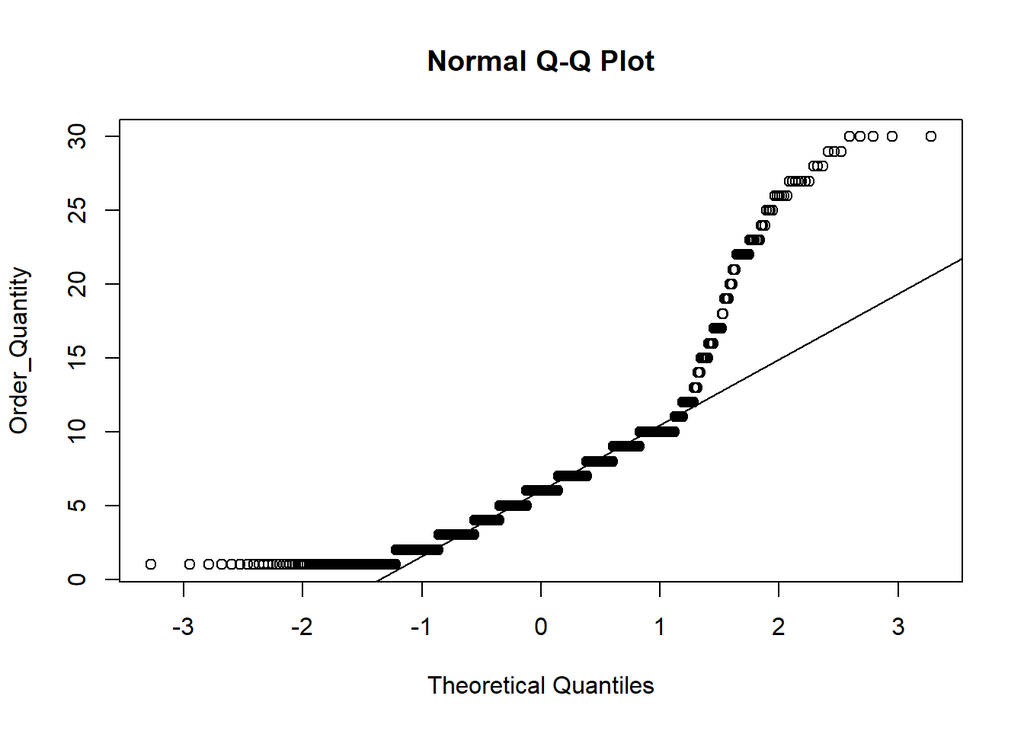

```r
# Checking the normality of 'Order_Quantity' variable
qqnorm(data$Order_Quantity, ylab = "Order_Quantity", xlab = "Theoretical Quantiles")
qqline(data$Order_Quantity)
```

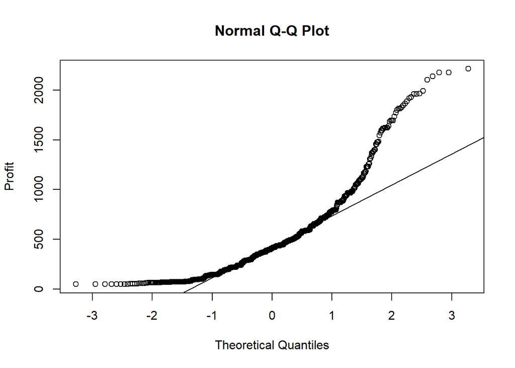

```r
# Checking the normality of 'Profit' variable
qqnorm(data$Profit, ylab = "Profit", xlab = "Theoretical Quantiles")
qqline(data$Profit)
```

Normality: The QQ-plots for both variables indicate departures from normality. However, as we have a large sample size, the central limit theorem suggests that the test results will be valid even if the data is not perfectly normal. Assumption 3: Homogeneity of Variances (using Fligner-Killeen test)

```r
fligner.test(data$Order_Quantity, data$Profit)
```

```
##
##  Fligner-Killeen test of homogeneity of variances
##
## data:  data$Order_Quantity and data$Profit
## Fligner-Killeen:med chi-squared = 466.89, df = 247, p-value = 9.963e-16
```

Homogeneity of Variances: The Fligner-Killeen test was used to assess the homogeneity of variances.The test resulted in a very small p-value (p < 0.001), indicating evidence against the null hypothesis of equal variances. Therefore, the assumption of homogeneity of variances may not hold.

#### Result: Give the output of the test and then write down the result (ex: since p value is less /greater than alpha, I reject/not reject the null hypothesis)

```r
# Perform independent samples t-test
t_test_result <- t.test(data$Order_Quantity, data$Profit)
# Print the result
print(t_test_result)
```

```
##
##  Welch Two Sample t-test
##
## data:  data$Order_Quantity and data$Profit
## t = -38.118, df = 949.41, p-value < 2.2e-16
## alternative hypothesis: true difference in means is not equal to 0
## 95 percent confidence interval:
##  -507.6863 -457.9706
## sample estimates:
##  mean of x  mean of y
##   7.001053 489.829474
```

The 95% confidence interval for the difference in means ranged from -507.6863 to -457.9706. The sample estimates for the mean of “Order_Quantity” and “Profit” were found to be 7.001053 and 489.829474 respectively.

#### What can be Type-1 and Type-2 error here? Not definition! Tell these situations in terms of data.

Type I Error: In this context, a Type I error would occur if we falsely conclude that there is a significant difference in means between the variables when, in reality, there is no true difference. Type II Error:In this context, a Type II error would occur if we fail to identify a significant difference in means between the variables when, in reality, there is a true difference. By conducting the independent samples t-test and considering the chosen level of significance (α), we aim to minimize these errors and make accurate conclusions based on the data.In this case, the highly significant p-value suggests a low probability of making a Type I error. However, it’s important to note that the presence of a significant association does not imply causation.

## ANOVA and Tukey Test

#### Assumption Check: Check the required assumptions statistically.

Before performing the ANOVA and Tukey test, it is important to check the required assumptions. The assumptions for ANOVA are as follows:

Normality: The data should be approximately normally distributed within each group. This assumption can be checked using a normality test such as the Shapiro-Wilk test or by visually inspecting the histograms or Q-Q plots of the data.

Homogeneity of variances: The variances of the groups should be approximately equal. This assumption can be checked using a test such as Levene’s test or by comparing the variances visually using boxplots.

Independence: The observations within each group should be independent of each other.

Now,let’s check these assumptions statistically for the given data:

Assumption 1: Normality We can perform the Shapiro-Wilk test for each group to check the normality assumption.We use the “shapiro.test()” function.

```r
# Shapiro-Wilk test for normality
shapiro.test(data$Profit)
```

```
##
##  Shapiro-Wilk normality test
##
## data:  data$Profit
## W = 0.84741, p-value < 2.2e-16
```

Normality Assumption: The Shapiro-Wilk test was performed to assess the normality assumption for the “Profit” variable. The results indicate that the data significantly deviates from a normal distribution (W = 0.84741, p < 2.2e-16). Therefore, the normality assumption is violated.

Assumption 2: Homogeneity of variances We can perform Levene’s test to check the homogeneity of variances assumption.

```r
# Levene's test for homogeneity of variances
leveneTest(data$Profit, data$Order_Quantity, center = median)
```

```
## Warning in leveneTest.default(data$Profit, data$Order_Quantity, center =
## median): data$Order_Quantity coerced to factor.
```

```
## Levene's Test for Homogeneity of Variance (center = median)
##        Df F value    Pr(>F)
## group  29  12.957 < 2.2e-16 ***
##       920
## ---
## Signif. codes:  0 '***' 0.001 '**' 0.01 '*' 0.05 '.' 0.1 ' ' 1
```

Homogeneity of Variances Assumption: The Levene’s test for homogeneity of variances was conducted to assess the assumption of equal variances between the “Profit” and “Order_Quantity” variables.

A warning message was displayed indicating that the “Order_Quantity” variable was coerced to a factor. The Levene’s test results show that there is a significant difference in variances between the groups (F = 12.957 < 2.2e-16). Thus, the assumption of homogeneity of variances is violated.

Assumption 3: Independence The assumption of independence is typically assumed to hold if the data is collected through a randomized experimental design or if the groups are naturally independent. It is important to ensure that the data points within each group are not correlated or dependent on each other.

```r
selected_data <- data
#Categorize "Revenue" variable
selected_data$Revenue <- cut(selected_data$Revenue,
                               breaks = c(0, 150, 300, Inf),
                               labels = c("0-150", "150-300", "300+"))

#Categorize "Order_Quantity" variable
selected_data$Order_Quantity <- cut(selected_data$Order_Quantity,
                                                breaks = c(1, 25, 64, Inf),
                                                labels = c("1-25", "25-64", "64+"))
# Categorize "Profit" variable
selected_data$Profit <- cut(selected_data$Profit,
                                             breaks = c(0, 200, 400, Inf),
                                             labels = c("0-200", "200-400", "400+"))
# Perform ANOVA
result <- aov(as.numeric(Revenue) ~ Order_Quantity + Profit, data = selected_data)
print(result)
```

```
## Call:
##    aov(formula = as.numeric(Revenue) ~ Order_Quantity + Profit,
##     data = selected_data)
##
## Terms:
##                 Order_Quantity      Profit   Residuals
## Sum of Squares     5.77000e-33 1.59650e-31 1.66087e-28
## Deg. of Freedom              1           2         840
##
## Residual standard error: 4.446601e-16
## Estimated effects may be unbalanced
## 106 observations deleted due to missingness
```

```r
#Perform Tukey's HSD test
tukey_result <- TukeyHSD(result)

#  Print the Tukey result
print(tukey_result)
```

```
##   Tukey multiple comparisons of means
##     95% family-wise confidence level
##
## Fit: aov(formula = as.numeric(Revenue) ~ Order_Quantity + Profit, data = selected_data)
##
## $Order_Quantity
##            diff           lwr          upr p adj
## 25-64-1-25    0 -1.807429e-16 1.807429e-16     1
##
## $Profit
##               diff           lwr          upr p adj
## 200-400-0-200    0 -1.166425e-16 1.166425e-16     1
## 400+-0-200       0 -1.064870e-16 1.064870e-16     1
## 400+-200-400     0 -8.233594e-17 8.233594e-17     1
```

## Multiple Linear Regression

#### Aim In words, what is our objective here? Not definition, talk about our own aim/problem.

The aim of this analysis is to investigate the relationship between the number of “Order_Quantity” and the variable “Profit”

#### Regression Equation: Write down the “statistical/mathematical equation” of regression function using those variables and the parameters.

The regression equation derived from the analysis is as follows: Order_Quantity = β0 + β1 * Profit

#### Variable Selection: Multiple linear regression (MLR) is a statistical technique that uses several explanatory variables to predict the outcome of a response variable. Which ones are the explanatory variables and which one is the response variable?

Here, “Order_Quantity” represents the response variable, and “Profit” is the explanatory variable. The coefficients β0 and β1 represent the intercept and slope, respectively, of the regression line.

#### Hypothesis and level of significance Write the hypothesis in scientific form and determine the level of significance.

The hypothesis for this analysis can be stated as follows: H0 (Null hypothesis): The number of Order_Quantity is not significantly influenced by the variable “Profit”. H1 (Alternative hypothesis): The number of Cost is significantly influenced by the variable “Profit”.The significance level (alpha) used in this analysis was set at 0.05 (or a confidence level of 95%).

#### Find the Best Model: Use step function and find the best model, describe the reason which makes it the best one.

```r
#Stepwise Regression Find the Best Model:
best_model <- step(lm(Order_Quantity ~Profit, data), direction = "both")
```

```
## Start:  AIC=899.95
## Order_Quantity ~ Profit
##
##          Df Sum of Sq     RSS    AIC
## <none>                 2439.6  900.0
## - Profit  1     28445 30885.0 3309.5
```

By using the stepwise regression approach, the best model was determined. The chosen model,based on the given output, is the one that includes only the “Profit” variable as a predictor for the number of Order_Quantity The selection of this model is based on its AIC value, which is 899.95.

#### Assumption Check: Check the required assumptions statistically.

Linearity: The regression analysis assumes a linear relationship between the response variable and the explanatory variable. Based on the chosen model, we assume a linear relationship between the number of Order_Quantity and Profit.

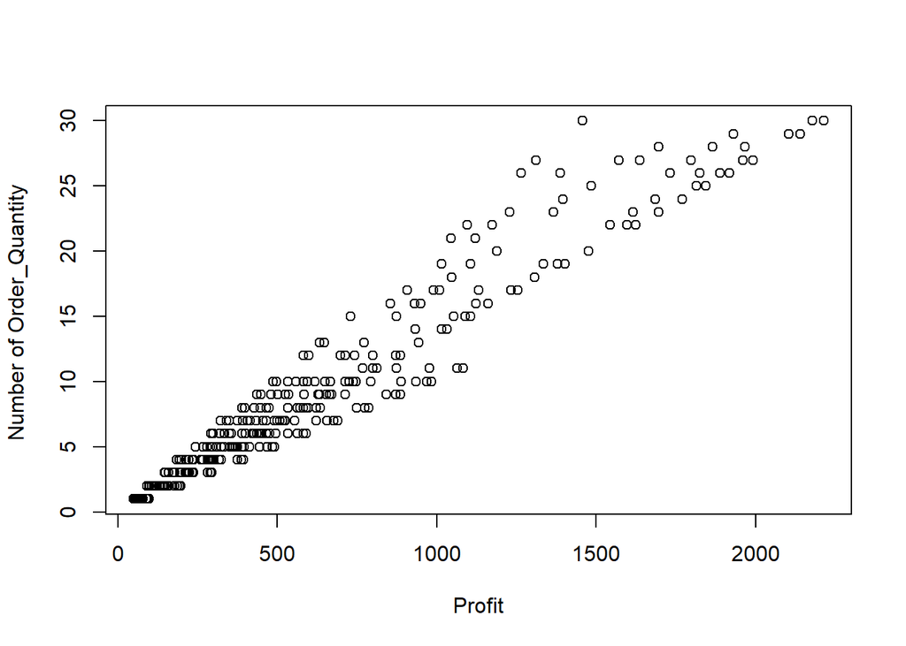

```r
# Scatter plot
plot(data$Profit, data$Order_Quantity, xlab = "Profit", ylab = "Number of Order_Quantity ")
```

The scatter plot shows a moderate dispersion of data points, with values ranging from 0 to 2000 for Profit and 0 to 30 for Order_Quantity . There is no significant deviation in the slope, indicating a linear relationship between the variables.In summary, the scatter plot confirms a linear relationship between Profit and Order_Quantity.

Independence: The observations are assumed to be independent of each other. The data collection method and sampling technique should ensure independence of observations.

Normality: The assumption of normality states that the error terms in the model are normally distributed. We can assess this assumption by examining the normality of the residuals.

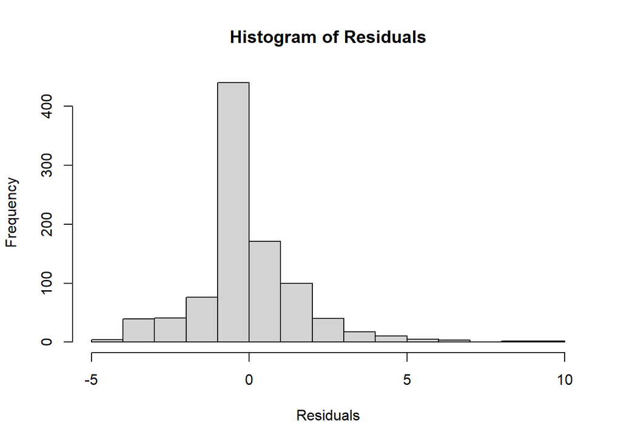

```r
residuals <- resid(best_model)
hist(residuals, main = "Histogram of Residuals", xlab = "Residuals")
```

When the residuals are at 0, the frequency is high, indicating that observations close to these values are well predicted by the model. This demonstrates that the model accurately predicts some examples in the dataset. As the residuals move towards -5 and +5, the frequency decreases almost by a factor of 1/5. This indicates that the model makes more errors in some predictions, and as these errors increase, they occur less frequently.

In other words, the model’s ability to predict higher or lower values is weaker compared to the values in the middle range.

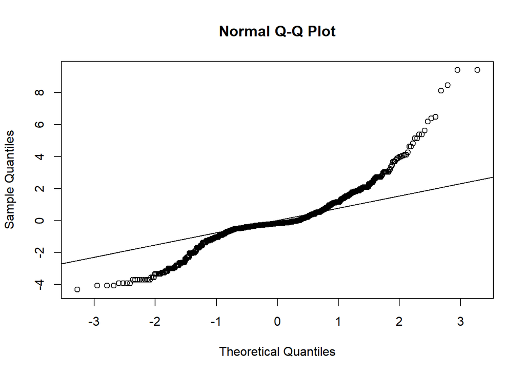

```r
#normality plots
qqnorm(residuals)
qqline(residuals)
```

Homoscedasticity: Homoscedasticity assumes that the error terms have constant variance. In other words, the spread of the residuals should be consistent across all levels of the explanatory variable.

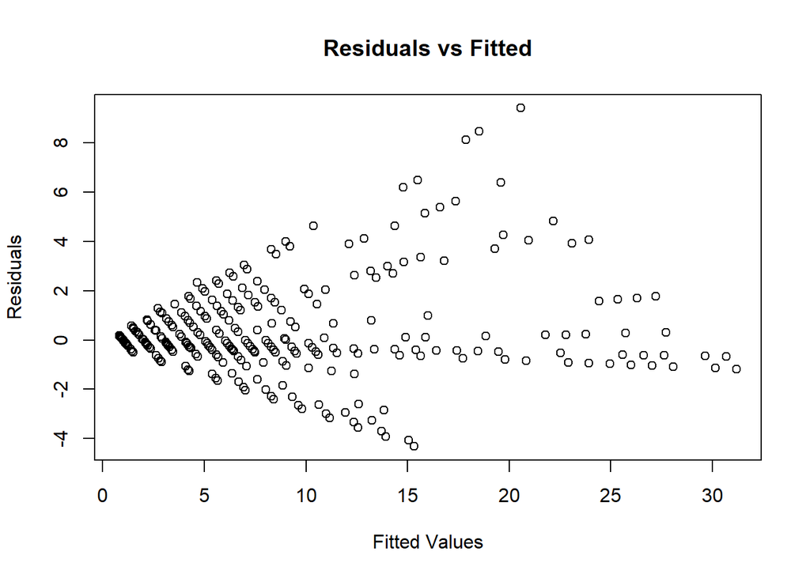

```r
residuals <- resid(best_model)
plot(fitted(best_model), residuals, xlab = "Fitted Values", ylab = "Residuals", main = "Residuals vs Fitted")
```

In the examination of homoscedasticity, it can be observed that there are numerous points around 0 residuals in the range of fitted values from 0 to 6. In other regions, the residuals are scattered more lightly. This suggests the presence of potential heteroscedasticity in the data. Heteroscedasticity occurs when the spread of residuals is not consistent across different levels of the explanatory variable.It is important to investigate the impact of heteroscedasticity on the regression results and consider appropriate adjustments if necessary.

#### Result: Give the output of the best model and write down the result.

```r
summary(best_model)
```

```
##
## Call:
## lm(formula = Order_Quantity ~ Profit, data = data)
##
## Residuals:
##     Min      1Q  Median      3Q     Max
## -4.3201 -0.5057 -0.1832  0.5308  9.4206
##
## Coefficients:
##              Estimate Std. Error t value Pr(>|t|)
## (Intercept) 0.1313016  0.0835360   1.572    0.116
## Profit      0.0140248  0.0001334 105.137   <2e-16 ***
## ---
## Signif. codes:  0 '***' 0.001 '**' 0.01 '*' 0.05 '.' 0.1 ' ' 1
##
## Residual standard error: 1.604 on 948 degrees of freedom
## Multiple R-squared:  0.921,  Adjusted R-squared:  0.9209
## F-statistic: 1.105e+04 on 1 and 948 DF,  p-value: < 2.2e-16
```

This equation demonstrates that the Profit variable has a statistically significant effect on the number of Order_Quantity. An increase in the number of Profit units is associated with an increase in the number of Order_Quantity .The R-squared value is calculated as 0.921, indicating that approximately 92.1% of the variation in the number of Order_Quantity can be explained by the Profit variable in the model.

#### Conclusion (4p):You got your result in item f. Write down the conclusion of the result, in such a way that, the reader who doesn’t know any statistics can understand your findings.

Based on our findings, the analysis revealed a relationship between the number of Profit and the number of Order_Quantity. An increase in the number of Profit was found to be associated with an increase in the number of Order_Quantity. This highlights the importance of Profits.

In conclusion, we can say that the number of Profit is an important factor in determining the number of Order_Quantity.